# 03 Estimaciones

LMT

abril de 2022

Usaremos datos ficticios de `Tlaxcala` similares a los del Censo 2010.

**Descripción de los datos**

Para el levantamiento de la muestra censal 2010 se diseñó un cuestionario ampliado, con el que fueron censadas alrededor de 2.9 millones de viviendas en el país, seleccionadas con criterios probabilísticos.

Consta de 2 cuestionarios: básico y ampliado.

**Objetivos**. Por medio de la muestra censal se estiman tasas, promedios y proporciones.

**Diseño**. El diseño de la muestra censal 2010 es estratificado por conglomerados y se realizó en una sola etapa de selección, es decir, se seleccionan áreas geográficas completas, ya sean manzanas o localidades. Dentro de estas áreas se aplica el cuestionario ampliado a todas las viviendas particulares habitadas

```r
# Limpiar área de trabajo
rm(list = ls())
```

```r
# Cargar librerías
suppressMessages(library(tidyverse))
library(ggplot2)
library(readr)
library(stringr)

library(haven)
```

Leer datos de viviendas

```r
viviendas_29b <- read_sas("/home/leonardo/Documentos/Acatlan/Datos/Censo_2010/MC2010_29_sas/viviendas_29b.sas7bdat", NULL) %>%
                  # crear variables númericas para el número de cuartos y elnúmero de personas
                  mutate(TOTAL_CUARTOS = as.numeric(TOTCUART),
                         NUM_PERSONAS = as.numeric(NUMPERS))
#glimpse(viviendas_29b)
```

Datos poblacionales

Número de municipios y agebs

```r
viviendas_29b %>% summarise(num_municipios = n_distinct(MUN), num_agebs = n_distinct(AGEB))
```

```
## # A tibble: 1 x 2
##   num_municipios num_agebs
##            <int>     <int>
## 1             60       392
```

Número de viviendas y personas

```r
viviendas_29b %>% summarise(num_viviendas = n_distinct(ID_VIV), num_personas = sum(NUM_PERSONAS))
```

```
## # A tibble: 1 x 2
##   num_viviendas num_personas
##           <int>        <dbl>
## 1        274245      1169936
```

**participación alumnos**. ¿recuerdan qué es una ageb?.

El Marco Geoestadístico Nacional es un sistema único y de carácter nacional diseñado por el INEGI para referenciar correctamente la información estadística de los censos y encuestas con los lugares geográficos correspondientes. El Marco Geoestadístico Nacional está conformado por áreas geoestadísticas. Una **ageb** (área geoestadística básica) constituye la unidad básica del Marco Geoestadístico Nacional.Para mayor referencia consultar la cartografía estadística del INEGI.

Graficar las áreas geograficas de municipios y distritos electorales para ver como nos conviene segmentar los conglomerados.

```r
#Cargar librería para graficar mapas
library(sf)
```

Los shapefiles del marco geoestadístico 2010 del INEGI pueden descargarse del siguiente enlace [Cartografía INEGI](https://www.inegi.org.mx/temas/mg/#Descargas)

```r
# Leer el dataframe de shapes de municipios
shapes_municipios <- st_read("/home/leonardo/Documentos/Acatlan/Datos/SHAPEFILES/marco_geoestadistico_2010/municipios/Municipios_2010_5.shp")
```

Los shapefiles de los distritos electorales pueden descargarse del siguiente enlace [Cartografía IFE](http://cartografia.ife.org.mx/sige7/?distritacion=local)

```r
# Leer el dataframe que contiene los poligonos de los distritos electorales de Tlaxcala
shapes_distritos_tlaxcala <- st_read("/home/leonardo/Documentos/Acatlan/Datos/SHAPEFILES/cartografia_ife/29/DISTRITO_LOCAL.shp")
shapes_municipios_tlaxcala <- shapes_municipios %>% filter(CVE_ENT == '29')
```

A continuación se muestra el mapa de Tlaxcala dividido por municipios

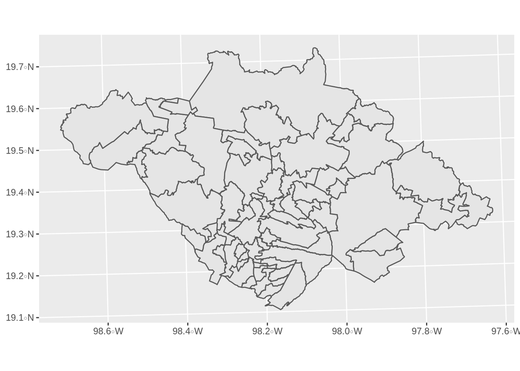

```r
ggplot(shapes_municipios_tlaxcala) +
  geom_sf()
```

Así se ve el mapa de Tlaxcala dividido por distritos electorales del INE.

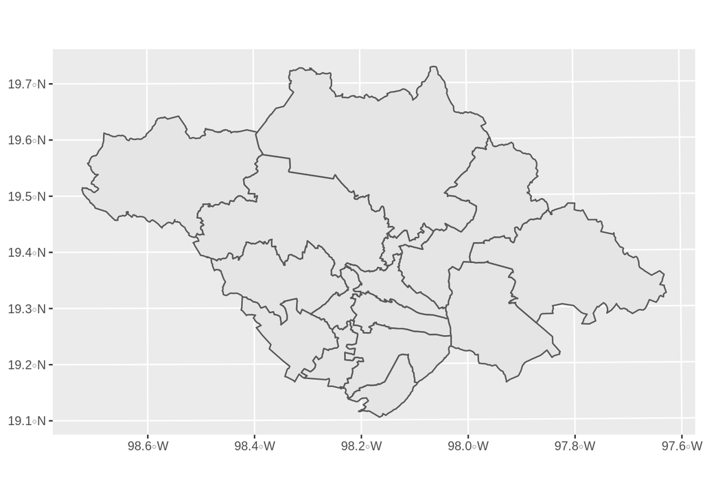

```r
ggplot(shapes_distritos_tlaxcala) +
  geom_sf()
```

**participación alumnos**. Con la información que disponemos, ¿es posible que los congomerados sean distritos electorales?.

## Estimación de Totales.

Estimar el Total de Personas utilizando los datos de Viviendas.

Tomar muestras en 2 etapas para distintos número de conglomerados y distintos tamaños de muestra. Notar que la muestra Tlaxcala en los microdatos del censo de 2010 es aproximadamente de 50,000 viviendas.

Para cada muestra, calcular la varianza del estimador. Reportar el valor de cada componente de la varianza (varianza entre clusters y varianza dentro de los clusters).

**Ejemplo 1**

Realizar el ejercico por pasos

Nuestros conglomerados serán los municipios

```r
# Obtener los distintos Clusters
clusters <- viviendas_29b %>% select(MUN) %>% pull() %>% unique()
print(clusters)
```

```
##  [1] "001" "002" "003" "004" "005" "006" "007" "008" "009" "010" "011" "012"
## [13] "013" "014" "015" "016" "017" "018" "019" "020" "021" "022" "023" "024"
## [25] "025" "026" "027" "028" "029" "030" "031" "032" "033" "034" "035" "036"
## [37] "037" "038" "039" "040" "041" "042" "043" "044" "045" "046" "047" "048"
## [49] "049" "050" "051" "052" "053" "054" "055" "056" "057" "058" "059" "060"
```

```r
# Obtener el número total de clusters
N <- length(clusters)
print(N)
```

```
## [1] 60
```

Tenemos 60 conglomerados.

**Ejercicio SAS**. Cargar la tabla de viviendas de Tlaxcala (viviendas_29b.sas7bdat) y obtener el número de conglomerados si en lugar de municipios, utilizaramos la variable de agebs.

Hagamos pruebas para ver como afecta a la varianza el número de conglomerados elegidos.

```r
# asignar el valor de n (el número de clusters que seleccionaremos en la muestra)
n <- 20

# slececcionar los 20 clusters de manera aleatoria
set.seed(1234)
sample_clusters <- sample(clusters,n)
print(sample_clusters)
```

```
##  [1] "028" "016" "058" "022" "037" "044" "047" "009" "005" "038" "059" "004"
## [13] "034" "039" "057" "026" "006" "015" "014" "042"
```

```r
# declarar el tamaño de muestra total que se seleccionará.
k <- 50000


#Asignar el tamaño de muestra de manera proporcional para cada cluster

tabla_aux1 <- viviendas_29b %>%
              filter(MUN %in% sample_clusters) %>%  # sólo conservar los clusters que salieron en la muestra
              group_by(ENT,MUN) %>%
              summarise(Mi = n()) %>%
              mutate(mi = round(k*(Mi/sum(Mi))), # asignar la muestra de manera proporcional
                     f1 = (N/n), # determinar el factor para cada cluster
                     f2 = Mi/mi, # determinar el factor dentro de cada cluster
                     factor = f1*f2,
                     unos = 1) %>%  # factor total para cada elemento
              ungroup() %>% # desagrupar
              arrange(desc(Mi)) # ordenar por el cluster con mayor número de elementos
print(tabla_aux1)
```

```
## # A tibble: 20 x 8
##    ENT   MUN      Mi    mi    f1    f2 factor  unos
##    <chr> <chr> <int> <dbl> <dbl> <dbl>  <dbl> <dbl>
##  1 29    005   19577 10293     3  1.90   5.71     1
##  2 29    006   10836  5697     3  1.90   5.71     1
##  3 29    034    9377  4930     3  1.90   5.71     1
##  4 29    044    8948  4705     3  1.90   5.71     1
##  5 29    015    8458  4447     3  1.90   5.71     1
##  6 29    028    4738  2491     3  1.90   5.71     1
##  7 29    039    4690  2466     3  1.90   5.71     1
##  8 29    026    4314  2268     3  1.90   5.71     1
##  9 29    038    3657  1923     3  1.90   5.71     1
## 10 29    004    3593  1889     3  1.90   5.71     1
## 11 29    014    3253  1710     3  1.90   5.71     1
## 12 29    042    2999  1577     3  1.90   5.71     1
## 13 29    037    1807   950     3  1.90   5.71     1
## 14 29    058    1781   936     3  1.90   5.71     1
## 15 29    016    1690   889     3  1.90   5.70     1
## 16 29    059    1370   720     3  1.90   5.71     1
## 17 29    022    1245   655     3  1.90   5.70     1
## 18 29    009    1156   608     3  1.90   5.70     1
## 19 29    057     977   514     3  1.90   5.70     1
## 20 29    047     634   333     3  1.90   5.71     1
```

Visualizar que conglomerados fueron seleccionados.

Unir la info de la tabla auxiliar a la tabla de los shapes de Tlaxcala

```r
conglomerados_seleccionados <- shapes_municipios_tlaxcala %>%
  left_join(tabla_aux1, by = c("CVE_ENT" = "ENT","CVE_MUN"="MUN")) %>%
  mutate(clave_etiqueta = ifelse(is.na(unos),"",CVE_MUN))
```

Crear mapa

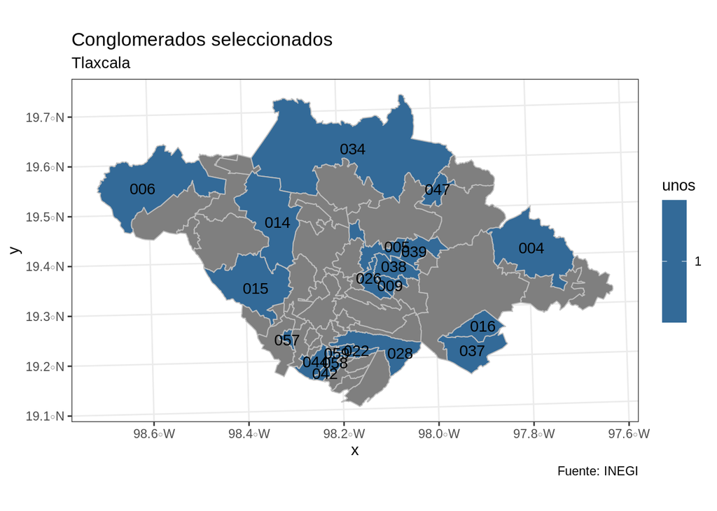

```r
conglomerados_seleccionados %>%
  ggplot(aes(fill = unos)) +
  geom_sf(colour = "grey", size = 0.35) +
  labs(title = "Conglomerados seleccionados",
       subtitle = "Tlaxcala",
       caption = "Fuente: INEGI") +
  theme_bw()  +
  geom_sf_text(aes(label = clave_etiqueta))
```

Si replican el ejemplo, muy seguramente obtendrán otros conglomerados por su versión de R y su sistema operativo.

**Ejercicio SAS**. ¿Qué municipio de los seleccionados tiene mayor número de personas?

Así como lo haciamos en muestreo estratificado, extraigamos una muestra de forma similar para cada conglomerado elegido.

```r
# De la tabla auxiliar extraigamos los vectores que nos ayudarán a hacer la muestra para cada cluster

vector_clusters <- tabla_aux1 %>% select(MUN) %>% pull()
vector_factores <- tabla_aux1 %>% select(factor) %>% pull()
vector_f1 <- tabla_aux1 %>% select(f1) %>% pull()
vector_f2 <- tabla_aux1 %>% select(f2) %>% pull()
vector_Mi <- tabla_aux1 %>% select(Mi) %>% pull()
vector_mi <- tabla_aux1 %>% select(mi) %>% pull()

# Inicia proceso para crear muestra

muestra_por_conglomerados <- viviendas_29b %>% filter(0 == 1)

# Fijar semilla
set.seed(2022)
for (i in 1:length(vector_clusters)) {
  muestra_i <- viviendas_29b %>%
    # Filtrar registros del cluster correspondiente
    filter(MUN == vector_clusters[i]) %>%
    # Obtener muestra de tamaño correspondiente
    sample_n(vector_mi[i]) %>%
    # Agregar el factor de expansión
    mutate(factor_total = vector_factores[i],
           f1 = vector_f1[i],
           f2 = vector_f2[i],
           # Agregar los valores del total de elementos y el número de elementos en la muestra
           Mi = vector_Mi[i],
           mi = vector_mi[i])

# Hacer un append a la tabla muestra
muestra_por_conglomerados <- bind_rows(muestra_por_conglomerados, muestra_i)
}
```

**participación alumnos**. Plantear los pasos para crear una muestra por conglomerados en 2 etapas usando SAS.

```r
glimpse(muestra_por_conglomerados)
```

```
## Rows: 50,001
## Columns: 47
## $ APELLIDO      <chr> "0", "0", "0", "0", "0", "0", "0", "0", "0", "0", "0", "…
## $ ENT           <chr> "29", "29", "29", "29", "29", "29", "29", "29", "29", "2…
## $ MUN           <chr> "005", "005", "005", "005", "005", "005", "005", "005", …
## $ AGEB          <chr> "0522", "0397", "0058", "0715", "0414", "0306", "0058", …
## $ LOC           <chr> "0001", "0001", "0001", "0001", "0001", "0001", "0001", …
## $ MZA           <chr> "011", "010", "032", "025", "007", "036", "025", "015", …
## $ SEG           <chr> "N", "N", "N", "N", "N", "N", "N", "N", "N", "N", "N", "…
## $ ID_VIV        <chr> "02027989", "02662008", "20393000", "22080968", "0082406…
## $ ID_SEG        <chr> "0343599", "0429104", "1778094", "1916694", "0141255", "…
## $ CONSVIV       <chr> "0006", "0015", "0071", "0033", "0003", "0018", "0077", …
## $ CLAVIVP       <chr> "1", "1", "1", "1", "1", "1", "2", "1", "1", "2", "1", "…
## $ CLAVIVC_C     <chr> "", "", "", "", "", "", "", "", "", "", "", "", "", "", …
## $ PISOS         <chr> "2", "3", "2", "3", "2", "3", "3", "2", "3", "3", "2", "…
```

[output cut: 34 more lines]

Saquemos algunos conteos para ver la información en la muestra. Se observan unos problemas de calidad en la variable total de cuartos. De acuerdo con el diccionario de datos del cuestionario, los 99s corresponden a la categoría no especificado.

```r
muestra_por_conglomerados %>% group_by(MUN) %>% summarise(n = n(), max_pers = max(NUM_PERSONAS), max_cuartos = max(TOTAL_CUARTOS))
```

```
## # A tibble: 20 x 4
##    MUN       n max_pers max_cuartos
##    <chr> <int>    <dbl>       <dbl>
##  1 004    1889       17          NA
##  2 005   10293       20          NA
##  3 006    5697       21          NA
##  4 009     608       18          99
##  5 014    1710       16          NA
##  6 015    4447       23          99
##  7 016     889       19          99
##  8 022     655       15          99
##  9 026    2268       18          99
## 10 028    2491       17          NA
## 11 034    4930       25          99
## 12 037     950       22          NA
## 13 038    1923       13          NA
## 14 039    2466       17          NA
## 15 042    1577       16          NA
## 16 044    4705       18          NA
## 17 047     333       16          99
## 18 057     514       12          99
## 19 058     936       15          NA
## 20 059     720       14          99
```

Hacer la estimación para el total de personas

```r
# De manera directa
estimacion_total_personas <-  muestra_por_conglomerados %>%  summarise(estimacion_total_personas = sum(factor_total*NUM_PERSONAS)) %>% pull()
estimacion_total_personas
```

```
## [1] 1199235
```

```r
# Estimación para cada cluster
muestra_por_conglomerados %>% group_by(MUN) %>% summarise(total_personas = sum(f2*NUM_PERSONAS))
```

```
## # A tibble: 20 x 2
##    MUN   total_personas
##    <chr>          <dbl>
##  1 004           16013.
##  2 005           76197.
##  3 006           44923.
##  4 009            5103.
##  5 014           13919.
##  6 015           35122.
##  7 016            6891.
##  8 022            5759.
##  9 026           18095.
## 10 028           21624.
## 11 034           39768.
## 12 037            8257.
## 13 038           14455.
## 14 039           21501.
## 15 042           12272.
## 16 044           38557.
## 17 047            2719.
## 18 057            4315.
## 19 058            7935.
## 20 059            6321.
```

```r
# sumar el total por cluster y multiplicar por el factor de expansión de los clusters

muestra_por_conglomerados %>% group_by(MUN) %>% summarise(total_personas = sum(f2*NUM_PERSONAS)) %>% summarise(total = (N/n)*sum(total_personas))
```

```
## # A tibble: 1 x 1
##      total
##      <dbl>
## 1 1199235.
```

Estimación de la varianza

**varianza entre clusters**

```r
tabla_aux_sb <- muestra_por_conglomerados %>%
                group_by(MUN) %>%
                summarise(yi_hat = sum(f2*NUM_PERSONAS))
tabla_aux_sb
```

```
## # A tibble: 20 x 2
##    MUN   yi_hat
##    <chr>  <dbl>
##  1 004   16013.
##  2 005   76197.
##  3 006   44923.
##  4 009    5103.
##  5 014   13919.
##  6 015   35122.
##  7 016    6891.
##  8 022    5759.
##  9 026   18095.
## 10 028   21624.
## 11 034   39768.
## 12 037    8257.
## 13 038   14455.
## 14 039   21501.
## 15 042   12272.
## 16 044   38557.
## 17 047    2719.
## 18 057    4315.
## 19 058    7935.
## 20 059    6321.
```

```r
# Calculamos la varianza de las estimaciones del total para los clusters
s2b <- tabla_aux_sb %>% summarise(var_yi = var(yi_hat)) %>% pull()

componente_s2b <-  (N**2)*(1-n/N)*(s2b/n)
componente_s2b
```

```
## [1] 41094800689
```

**varianza dentro de los clusters**

```r
tabla_aux_sw <- muestra_por_conglomerados %>%
                group_by(MUN) %>%
                summarise(s2wi = var(NUM_PERSONAS), Mi = mean(Mi), mi = mean(mi))  %>%
                mutate(sumando = (Mi**2)*(1-mi/Mi)*(s2wi/mi))
tabla_aux_sw
```

```
## # A tibble: 20 x 5
##    MUN    s2wi    Mi    mi sumando
##    <chr> <dbl> <dbl> <dbl>   <dbl>
##  1 004    4.56  3593  1889  14779.
##  2 005    3.53 19577 10293  62297.
##  3 006    3.83 10836  5697  37470.
##  4 009    4.76  1156   608   4957.
##  5 014    3.97  3253  1710  11662.
##  6 015    3.82  8458  4447  29157.
##  7 016    4.59  1690   889   6982.
##  8 022    3.91  1245   655   4382.
##  9 026    3.78  4314  2268  14700.
## 10 028    4.12  4738  2491  17611.
## 11 034    4.55  9377  4930  38470.
## 12 037    6.58  1807   950  10734.
## 13 038    3.23  3657  1923  10659.
## 14 039    4.38  4690  2466  18540.
## 15 042    3.85  2999  1577  10401.
## 16 044    4.16  8948  4705  33596.
## 17 047    4.19   634   333   2400.
## 18 057    4.07   977   514   3584.
## 19 058    3.90  1781   936   6273.
## 20 059    3.86  1370   720   4769.
```

```r
componente_s2wi <- tabla_aux_sw %>% summarise(estimador_varianza = (N/n)*sum(sumando)) %>% pull()
componente_s2wi
```

```
## [1] 1030271
```

**varialza total**

```r
varianza_total <- componente_s2b + componente_s2wi
varianza_total
```

```
## [1] 41095830960
```

**participación de los componentes en la varialza total**

```r
print(100*(componente_s2b/varianza_total))
```

```
## [1] 99.99749
```

```r
print(100*(componente_s2wi/varianza_total))
```

```
## [1] 0.002506997
```

**Intervalo de confianza**

Definir la confianza

```r
alpha <- 0.10
z <- qnorm(1-alpha/2)
z
```

```
## [1] 1.644854
```

Los límites del intervalo son

```r
ee <- sqrt(varianza_total)
print(ee)
```

```
## [1] 202721.1
```

```r
limite_inferior <- estimacion_total_personas - z*ee
limite_superior <- estimacion_total_personas + z*ee
c(limite_inferior,limite_superior)
```

```
## [1]  865788.7 1532681.7
```

Longitud del intervalo

```r
limite_superior - limite_inferior
```

```
## [1] 666893
```

**Ejercicio**. Modificar los valores de n y k (número de conglomerados seleccionados y tamaño de muestra total respectivamente).

- n = 1, 10, 15, 35, 50 y 60
- k = 10000, 25000, 50000, 70000, 85000 y 100000

**participación alumnos**. Considerando que los recursos son limitados y muchas veces no es factible poder realizar un censo; tomando como punto de referencia la estimación anterior, ¿qué ven más favorable, aumentar el número de conglomerados y disminuir el número de muestra o disminuir el número de conglomerados y aumentar el tamaño de muestra?.